# Principal Component Analysis (PCA)

20 de Novembro de 2014

## Preliminares

## O que é a PCA?

A PCA ('Principal Component Analysis') é uma ferramenta de análise exploratória dos dados, usada para simplificar as decrições de variação entre indivíduos. Ordena os objetos na sua análise, organizando-os em um espaço de forma.

## Qual a proposta da PCA?

- Simplificar padrões
- Substitui a variável original por novas variáveis (PCs)
- Combinações lineares das variáveis originais
- Independentes (não correlacionadas)

## Vantagens da PCA?

- Permite identificar padrões (abordagem de questões biológicas);
- A maior parte da variação na amostra geralmente pode ser descrita com poucos PCs;
- Simplifica e deixa claro o que deve ser explicado;
- Apresentação dos resultados é simplificada;
- Visualização gráfica das similaridades e diferenças;
- Fornece novas variáveis para análises estatísticas futuras;

## IMPORTANTE!!

- PCA NÃO deve ser usada como um teste de hipótese
- As diferenças visualizadas em gráfico de PCA não demonstram evidência de entidades distintas estatisticamente.

## Similaridades e diferenças podem ser vistas em um gráfico de PCA.

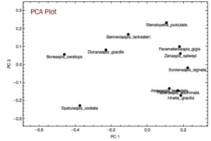

- Os eixos são os PCs
- Cada ponto representa a forma de um único objeto da sua análise
- Quanto mais próximos esses objetos são, mais similares eles serão em suas formas

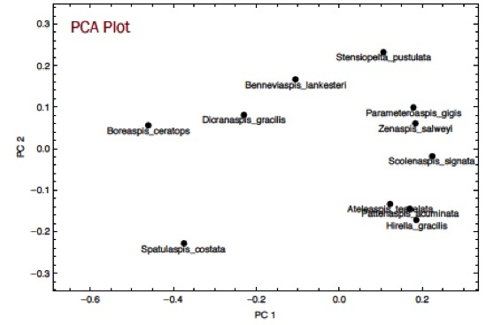

[figure not shown]

## Como a forma varia em um gráfico de PCA?

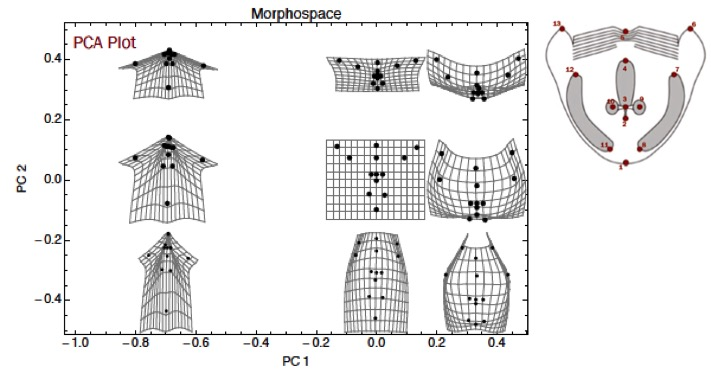

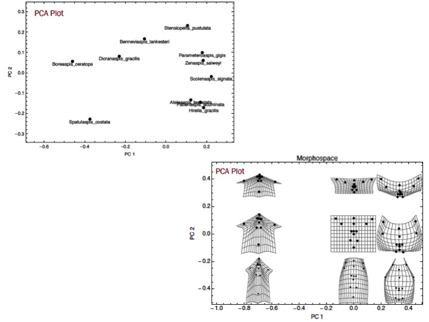

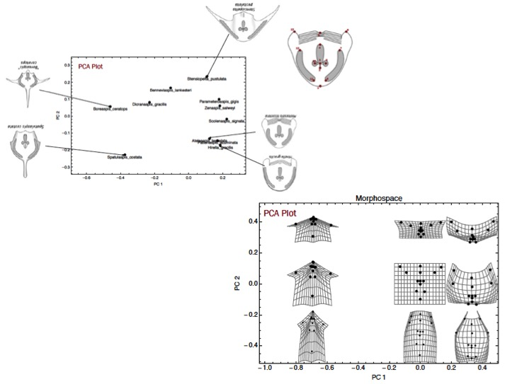

## Os PCs de um conjunto de dados são seus eixos de maior variação

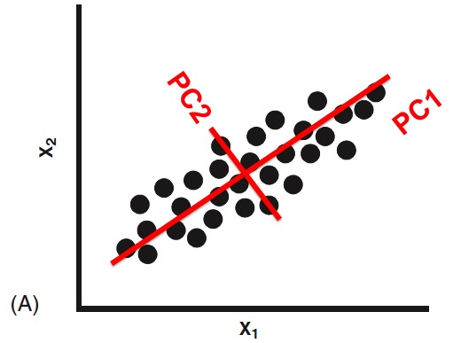

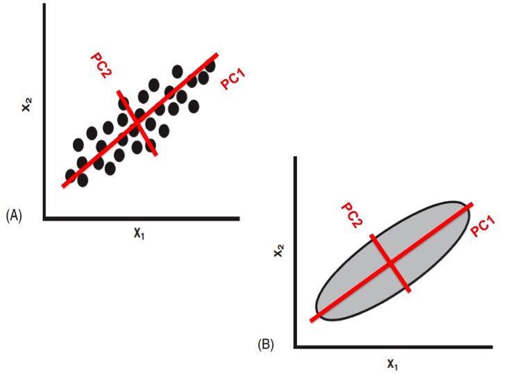

## Quais são os passos de uma PCA?

- Encontrar a direção (ou eixo) que descreve a maior proporção de variância total no seu conjunto de dados
- Rotacionar os dados para o eixo de maior variação
- Preserva as distâncias originais entre os dados
- Remove as correlações entre as variáveis

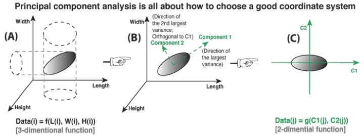

## A PCA também fornece

- Scores - coordenadas de cada ponto em cada eixo dos PCs (podem ser usadas como variáveis de forma em outras análises);
- Autovalores (eigenvalues) - variância em cada eixo dos PCs;
- Autovetores (eigenvectors) - loading de cada variável original em cada eixo dos PCs

## Geomorph

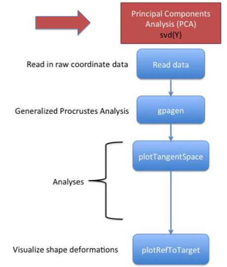

## plotTangentSpace

Retorna: pc.summary: A PC summary table (standard deviation, proportion of variance, cumulative proportion) pc.scores: The set of principal component scores for all specimens. pc.shapes: A list with four components of the shape coordinates of the extreme ends of axis1 and axis2 is returned, which can be used by warpRefMesh.